# Logistic Regression

```r
# Load libraries
library(tidyr); library(dplyr); library(ggplot2); library(GGally)
# Import data
alc <- read.table("http://s3.amazonaws.com/assets.datacamp.com/production/course_2218/datasets/alc.txt ", sep=",", header=TRUE)
```

The data used in this analysis is taken from school reports and questionnaires collected in 2008. It approaches student achievement in secondary education in two Portuguese schools and regard performance in two subjects: math (mat) and Portuguese language (por). The data has 382 observations and 35 variables.

```r
str(alc)
```

```
## 'data.frame':    382 obs. of  35 variables:
##  $ school    : Factor w/ 2 levels "GP","MS": 1 1 1 1 1 1 1 1 1 1 ...
##  $ sex       : Factor w/ 2 levels "F","M": 1 1 1 1 1 2 2 1 2 2 ...
##  $ age       : int  18 17 15 15 16 16 16 17 15 15 ...
##  $ address   : Factor w/ 2 levels "R","U": 2 2 2 2 2 2 2 2 2 2 ...
##  $ famsize   : Factor w/ 2 levels "GT3","LE3": 1 1 2 1 1 2 2 1 2 1 ...
##  $ Pstatus   : Factor w/ 2 levels "A","T": 1 2 2 2 2 2 2 1 1 2 ...
##  $ Medu      : int  4 1 1 4 3 4 2 4 3 3 ...
##  $ Fedu      : int  4 1 1 2 3 3 2 4 2 4 ...
##  $ Mjob      : Factor w/ 5 levels "at_home","health",..: 1 1 1 2 3 4 3 3 4 3 ...
##  $ Fjob      : Factor w/ 5 levels "at_home","health",..: 5 3 3 4 3 3 3 5 3 3 ...
##  $ reason    : Factor w/ 4 levels "course","home",..: 1 1 3 2 2 4 2 2 2 2 ...
##  $ nursery   : Factor w/ 2 levels "no","yes": 2 1 2 2 2 2 2 2 2 2 ...
##  $ internet  : Factor w/ 2 levels "no","yes": 1 2 2 2 1 2 2 1 2 2 ...
##  $ guardian  : Factor w/ 3 levels "father","mother",..: 2 1 2 2 1 2 2 2 2 2 ...
```

[output cut: 21 more lines]

```r
dim(alc)
```

```
## [1] 382  35
```

#### Analysis of variables

For this analysis I am interested in the following four variables and their relationship with alcohol consumption: sex (male or female), failures (number of past class failures), Dalc (workday alcohol consumption) and absences (number of school absences). I expect that failures, Dalc and absences will be indicators of a student who consumes higher levels of alcohol (high_use which is TRUE for students for which ‘alc_use’ is greater than 2 and FALSE otherwise). Additionally, I think that male students will be more likely to drink than female students.

```r
data(alc, package = "COUNT")
attach(alc)
table(high_use, sex)
```

```
##         sex
## high_use   F   M
##    FALSE 157 113
##    TRUE   41  71
```

```r
table(high_use, failures)
```

```
##         failures
## high_use   0   1   2   3
##    FALSE 234  22   5   9
##    TRUE   82  16   6   8
```

```r
table(high_use, Dalc)
```

```
##         Dalc
## high_use   1   2   3   4   5
##    FALSE 251  19   0   0   0
##    TRUE   17  54  24   8   9
```

```r
table(high_use, absences)
```

```
##         absences
## high_use  0  1  2  3  4  5  6  7  8  9 10 11 12 13 14 15 16 17 18 19 20 21
##    FALSE 94  2 54  2 36  4 19  6 13  3 12  1  6  0  7  1  2  0  2  0  1  1
##    TRUE  22  1 13  4 15  0 11  2  8  0  5  1  4  3  4  2  4  1  2  1  1  0
##         absences
## high_use 22 23 24 25 26 28 30 54 56 75
##    FALSE  0  1  0  1  1  0  0  0  0  1
##    TRUE   3  0  1  0  0  1  1  1  1  0
```

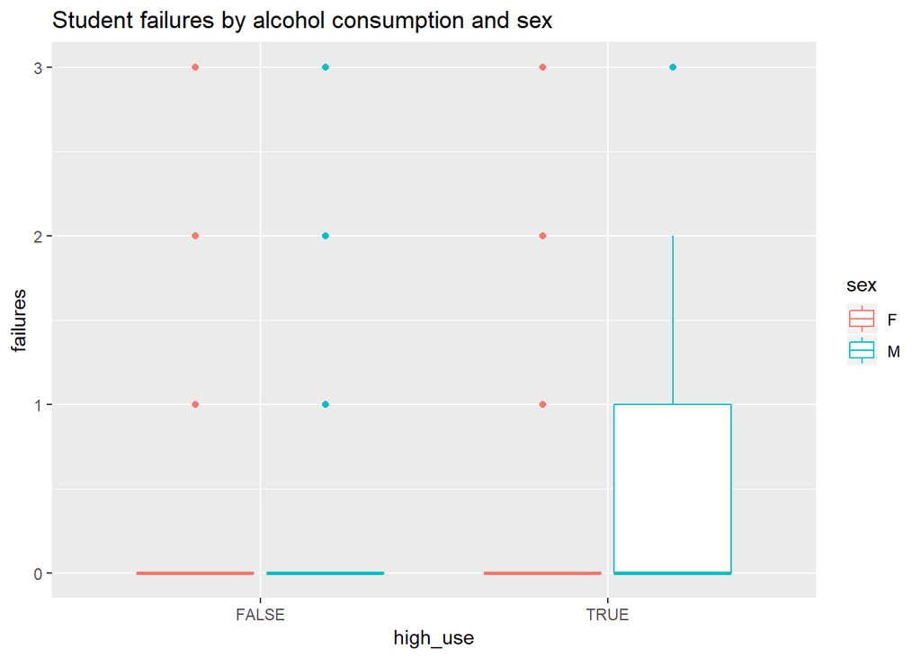

```r
g2 <- ggplot(alc, aes(x = high_use, y = failures, col = sex))
g2 + geom_boxplot() + ylab("failures") + ggtitle("Student failures by alcohol consumption and sex")
```

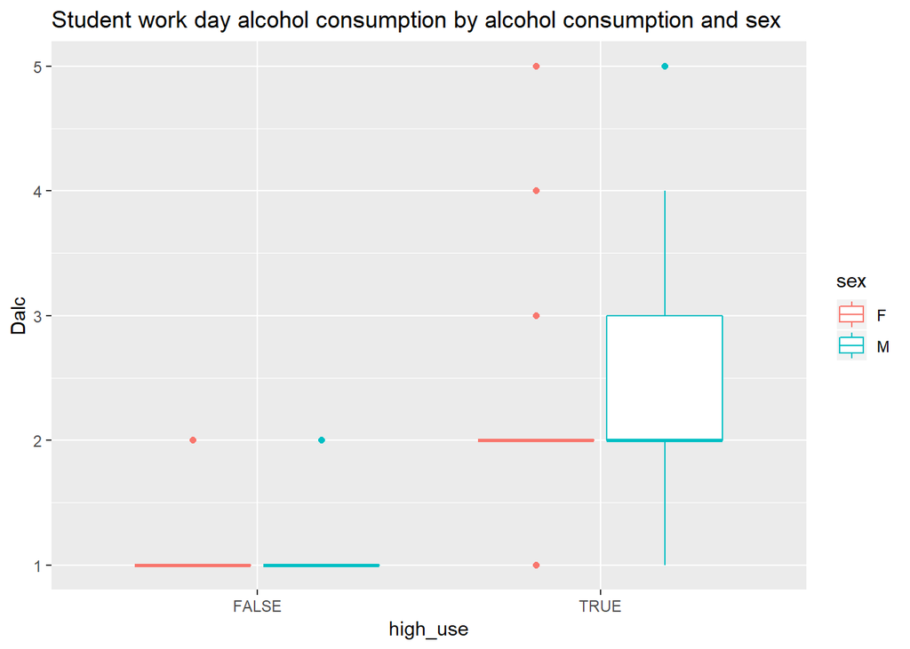

```r
g3 <- ggplot(alc, aes(x = high_use, y = Dalc, col = sex))
g3 + geom_boxplot() + ylab("Dalc") + ggtitle("Student work day alcohol consumption by alcohol consumption and sex")
```

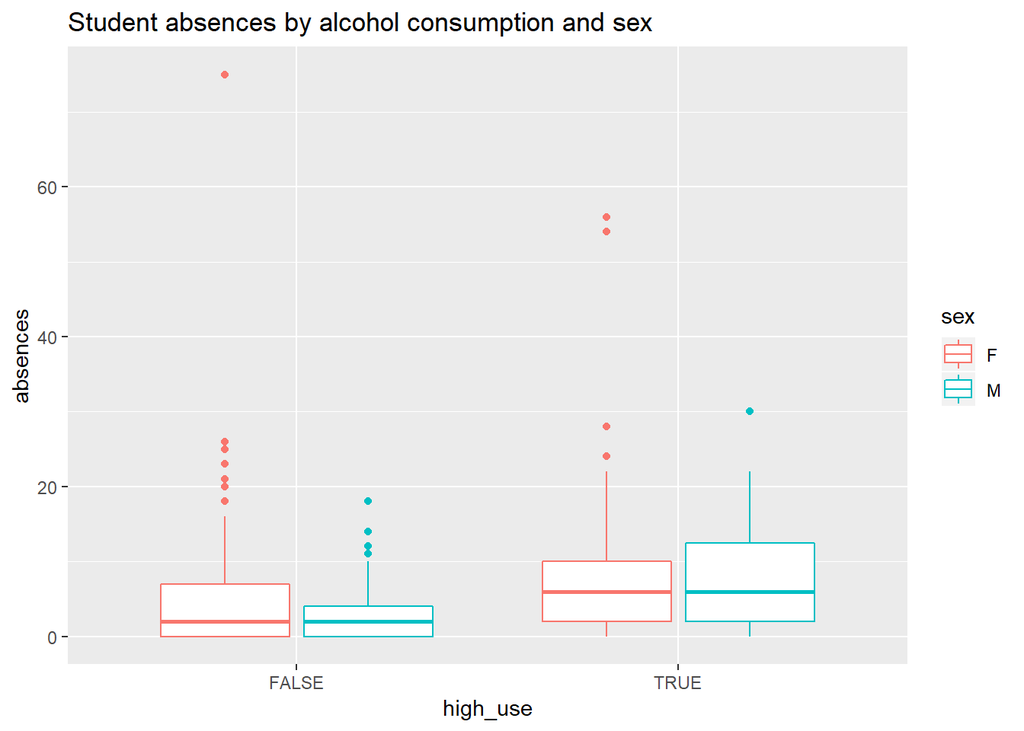

```r
g4 <- ggplot(alc, aes(x = high_use, y = absences, col = sex))
g4 + geom_boxplot() + ylab("absences") + ggtitle("Student absences by alcohol consumption and sex")
```

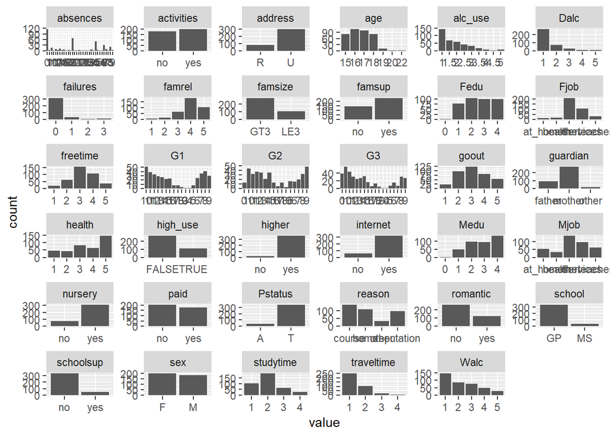

```r
gather(alc) %>% ggplot(aes(value)) + facet_wrap("key", scales = "free") + geom_bar()
```

### Logistic regression

```r
# find the model with glm()
m <- glm(high_use ~ failures + absences + sex + Dalc, data = alc, family = "binomial")

# print out a summary of the model
summary(m)
```

```
##
## Call:
## glm(formula = high_use ~ failures + absences + sex + Dalc, family = "binomial",
##     data = alc)
##
## Deviance Residuals:
##      Min        1Q    Median        3Q       Max
## -2.01794  -0.35645  -0.31186   0.01944   2.51487
##
## Coefficients:
##             Estimate Std. Error z value Pr(>|z|)
## (Intercept) -7.05268    0.64624 -10.913  < 2e-16 ***
## failures     0.10337    0.23988   0.431  0.66654
## absences     0.06870    0.02537   2.708  0.00676 **
## sexM         0.25731    0.37974   0.678  0.49803
## Dalc         3.79626    0.38054   9.976  < 2e-16 ***
## ---
## Signif. codes:  0 '***' 0.001 '**' 0.01 '*' 0.05 '.' 0.1 ' ' 1
##
## (Dispersion parameter for binomial family taken to be 1)
##
##     Null deviance: 462.21  on 381  degrees of freedom
## Residual deviance: 200.64  on 377  degrees of freedom
## AIC: 210.64
##
## Number of Fisher Scoring iterations: 6
```

```r
# print out the coefficients of the model
coef(m)
```

```
## (Intercept)    failures    absences        sexM        Dalc
##  -7.0526826   0.1033664   0.0687011   0.2573069   3.7962551
```

```r
# compute odds ratios (OR)
OR <- coef(m) %>% exp

# compute confidence intervals (CI)
CI <- confint(m) %>% exp
# print out the odds ratios with their confidence intervals
cbind(OR, CI)
```

```
##                       OR        2.5 %       97.5 %
## (Intercept) 8.650851e-04 2.204188e-04  0.002821578
## failures    1.108898e+00 6.895558e-01  1.761097992
## absences    1.071116e+00 1.025087e+00  1.132692332
## sexM        1.293442e+00 6.088437e-01  2.725976302
## Dalc        4.453410e+01 2.191099e+01 97.819016581
```

#### Analysis of the model

Of the four predictor variables, absences (p-value = 0.006) and Dalc (p-value = <0.001). This further supports my hypothesis that absences and Dalc are predictors of students who will classify as high_use. On the other hand, failure and gender are not statistically significant predictors.

#### Make predictions

```r
# fit the model
m <- glm(high_use ~ absences + Dalc, data = alc, family = "binomial")

# predict() the probability of high_use
probabilities <- predict(m, type = "response")

# add the predicted probabilities to 'alc'
alc <- mutate(alc, probability = probabilities)

# use the probabilities to make a prediction of high_use
alc <- mutate(alc, prediction = probability > 0.5)

# see the last ten original classes, predicted probabilities, and class predictions
select(alc, absences, Dalc, high_use, probability, prediction) %>% tail(10)
```

```
##     absences Dalc high_use probability prediction
## 373        0    1    FALSE  0.04256976      FALSE
## 374       14    4     TRUE  0.99991756       TRUE
## 375        2    1    FALSE  0.04838021      FALSE
## 376        7    2    FALSE  0.77125728       TRUE
## 377        0    1    FALSE  0.04256976      FALSE
## 378        0    1    FALSE  0.04256976      FALSE
## 379        0    1    FALSE  0.04256976      FALSE
## 380        0    1    FALSE  0.04256976      FALSE
## 381        3    3     TRUE  0.99189205       TRUE
## 382        0    3     TRUE  0.99010438       TRUE
```

```r
# tabulate the target variable versus the predictions
table(high_use = alc$high_use, prediction = probabilities > 0.5)
```

```
##         prediction
## high_use FALSE TRUE
##    FALSE   250   20
##    TRUE     17   95
```

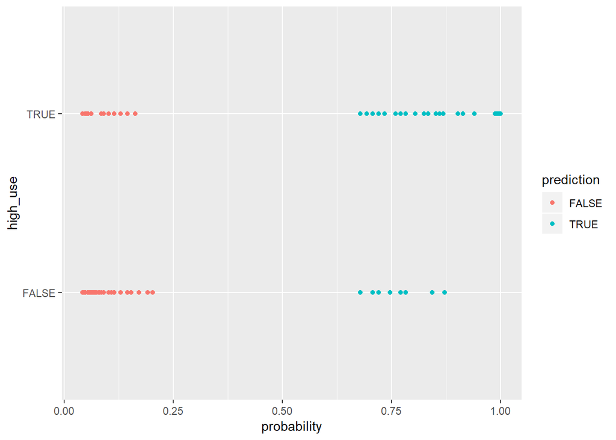

```r
# initialize a plot of 'high_use' versus 'probability' in 'alc'
g <- ggplot(alc, aes(x = probability, y = high_use, col = prediction))

# define the geom as points and draw the plot
g + geom_point()
```

```r
# tabulate the target variable versus the predictions
table(high_use = alc$high_use, prediction = alc$prediction) %>% prop.table() %>% addmargins()
```

```
##         prediction
## high_use      FALSE       TRUE        Sum
##    FALSE 0.65445026 0.05235602 0.70680628
##    TRUE  0.04450262 0.24869110 0.29319372
##    Sum   0.69895288 0.30104712 1.00000000
```

#### Accuracy of model

```r
# define a loss function (mean prediction error)
loss_func <- function(class, prob) {
  n_wrong <- abs(class - prob) > 0.5
  mean(n_wrong)
}

# call loss_func to compute the average number of wrong predictions in the (training) data
loss_func(class = alc$high_use, prob = alc$probability)
```

```
## [1] 0.09685864
```

```r
# define a loss function (average prediction error)
loss_func <- function(class, prob) {
  n_wrong <- abs(class - prob) > 0.5
  mean(n_wrong)
}

# compute the average number of wrong predictions in the (training) data
loss_func(class = alc$high_use, prob = alc$probability)
```

```
## [1] 0.09685864
```

#### 10 fold cross-validation

```r
# K-fold cross-validation
library(boot)
cv <- cv.glm(data = alc, cost = loss_func, glmfit = m, K = 10)

# average number of wrong predictions in the cross validation
cv$delta[1]
```

```
## [1] 0.09685864
```

### Analysis of predictions

In this model, 9% of the individuals were inaccurately classified. This figure remains the same even after conducting a 10-fold cross-validation. I would propose that a 91% prediction rate is a significant improvement on the results of a simple guessing strategy.